# ggplot의 X, Y축 숫자 포맷 설정

`ggplot`으로 플롯을 작성할 때 가끔 만나는 문제가 X축이나 Y축의 숫자인 label이 원하는 포맷으로 나오지 않을 때가 있다는 점이다.

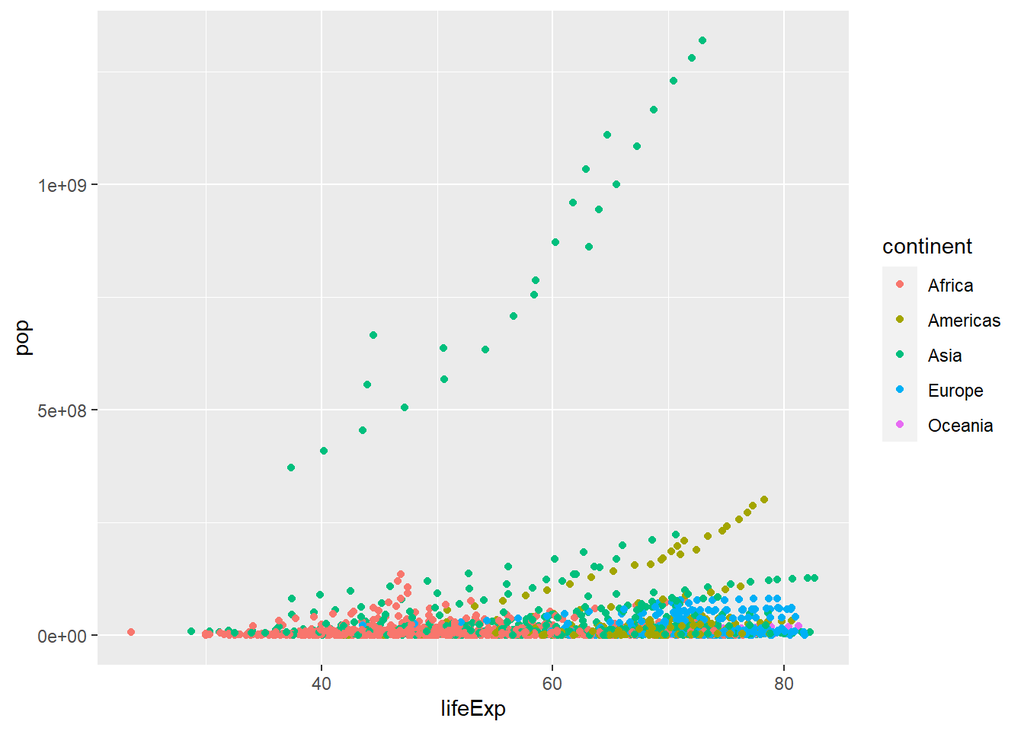

```r
library(tidyverse)
library(ggplot2)
if(!require(gapminder)) {
  install.packages('gapminder')
  library(gapminder)
}

gapminder %>%
  ggplot(aes(x = lifeExp, y = pop, color = continent)) +
  geom_point()
```

**1. scales_* 함수에 미리 정의된 숫자 포맷 지정**

ggplot에서 X축과 Y축의 형태를 변경할 수 있는 함수로 scale_* 함수가 사용된다. 이 함수에서 사용하는 매개변수인 `labels`는 X, Y축에서 표현되는 라벨의 표현 형태를 설정하는데 사용한다. 따라서 `labels` 매개변수를 `scales` 패키지에서 제공하는 포맷 지정 함수 중 적절한 함수를 지정해주면 표현되는 숫자의 형태가 변경된다.

`scales` 패키지에 `labels`에 설정할 수 있는 유용한 함수는 다음과 같다.

- number : 숫자 포맷으로 표현되나 천단위 구분에 빈칸을 사용하는 포맷
- comma : 숫자 포맷으로 천단위 구분 기호로 콤마(,)를 사용하는 포맷
- percent : 백분률 포맷으로 원값에 100을 곱한 값이 표시되며 접미어에 ’%’가 붙음
- dollar : 달러 통화 포맷으로 접두사에 ’$’가 붙음
- scientific : 과학적 포맷으로 지수형태의 표기

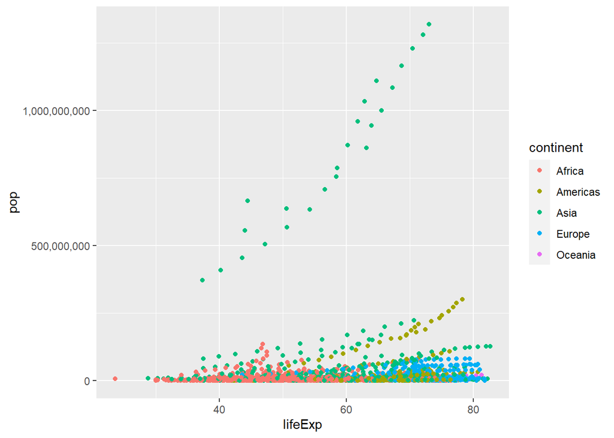

```r
gapminder %>%
  ggplot(aes(x = lifeExp, y = pop, color = continent)) +
  geom_point() +
  scale_y_continuous(labels = scales::comma)
```

여기서 하나 중요한 것은 포맷을 지정하는 `scales` 패키지의 함수를 설정할 때 일반적인 함수를 호출할 때 처럼 ()를 붙이면 안된다는 것이다. 이유는? 잘 모르겠지만 ()붙이면 에러가 난다.

**2. scales_* 함수에 숫자 포맷을 직접 설정**

다음으로 사용할 수 있는 방법은 앞선 사전 정의 포맷을 사용하는 대신 사용자가 직접 축 라벨에 사용될 포맷을 설정하는 방법이다. 포맷 설정에 사용하는 `sacles` 패키지의 함수는 `number_format()`이다. `number_format()`의 매개변수들을 적절히 설정함으로써 사용자가 원하는 형태의 숫자 형태로 출력이 가능하다.

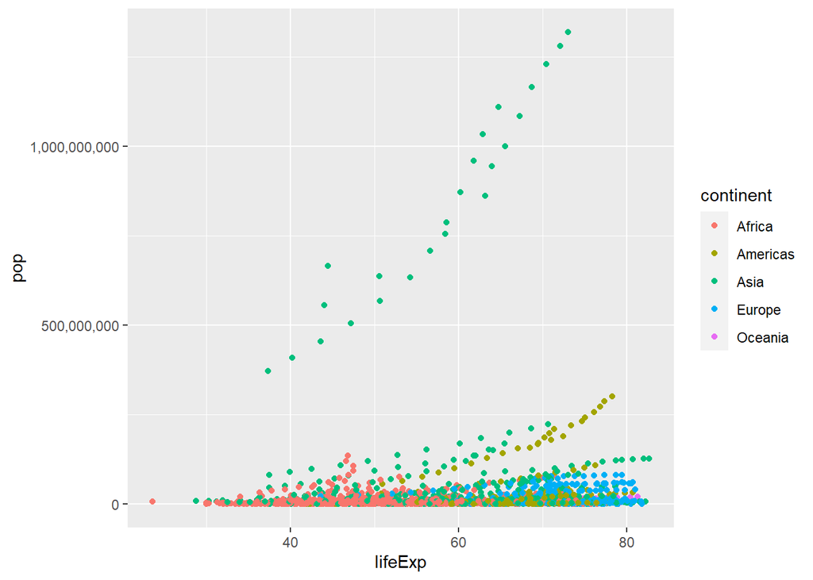

```r
gapminder %>%
  ggplot(aes(x = lifeExp, y = pop, color = continent)) +
  geom_point() +
  scale_y_continuous(labels = scales::number_format(big.mark = ','))
```

다음은 `number_format()`에서 사용하는 매개변수와 그 설명이다.

- accuracy : 반올림 되어 표기될 숫자의 유효숫자 범위를 지정. 예를 들어 0.01로 설정하면 소수점 세째자리에서 반올림하여 소수점 두쨰자리까지 표시됨.
- scale : 스케일 팩터를 지정. 표기될 숫자는 포맷팅 되기 전에 스케일 팩터가 곱해짐. 수치값이 매우 작거나 매우 클때 유용함.
- prefix : 숫자의 앞 에 표시될 문자 지정
- sufix : 숫자의 뒤에 표시될 문자 지정
- big.mark : 매 3자리(천단위)마다 표시될 문자 지정
- decimal.mark : 소수점으로 표시될 문자 지정